# FigureYa61 GSVA

小丫画图出品

2018-12-17

微信ID: epigenomics E-mail: figureya@126.com

作者：[Yu Sun](https://icannotendure.space/en/)，小丫

## 需求描述

模仿paper里方法做GSVA，结果保存到文件，能作为FigureYa39bar的输入文件画出bar plot。

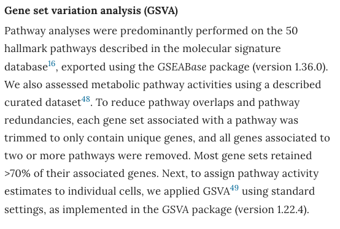

出自https://www.nature.com/articles/s41591-018-0096-5/

## 应用场景

关于GSVA分析，可以这样理解：如果说表达矩阵反映了样本和基因的关系，则GSVA将一个“样本×基因”的矩阵转化为“样本×通路”的矩阵，直接反映了样本和读者感兴趣的通路之间的联系。因此，如果用limma包做差异表达分析可以寻找样本间差异表达的基因，同样地，使用limma包对GSVA的结果（依然是一个矩阵）做同样的分析，则可以寻找样本间有显著差异的通路。这些“差异表达”的通路，相对于基因而言，更加具有生物学意义，更具有可解释性，是统计学与生物学成功结合后，对GSEA结果的一次升华，可以进一步用于肿瘤subtype的分型等等与生物学意义结合密切的探究。

示例文件easy_input_expr.csv跟FigureYa59volcano用的是同一套表达数据。

- FigureYa59volcano的输入文件easy_input_limma.csv是用**全体基因**做差异分析获得的。
- 此处gsva_limma.csv文件是用**通路**做差异分析获得的。

## 环境设置

### 安装包

```r
#使用国内镜像安装包
options("repos"= c(CRAN="https://mirrors.tuna.tsinghua.edu.cn/CRAN/"))
options(BioC_mirror="http://mirrors.ustc.edu.cn/bioc/")
install.packages("msigdbr")
```

### 加载包

```r
library(msigdbr)
library(dplyr)
library(data.table)
```

```r
library(GSVA)
library(limma)
library(stringr)
library(ggplot2)

Sys.setenv(LANGUAGE = "en") #显示英文报错信息
options(stringsAsFactors = FALSE) #禁止chr转成factor
# options(mc.cores = parallel::detectCores())
```

## 输入文件

GSVA需要两个输入文件：基因表达矩阵和通路里的基因列表。

- hallmark.gs.RData：“整理通路里的基因列表”这部分生成的，同一物种同一版本注释可重复使用。
- easy_input_expr.csv：基因表达矩阵，每行一个基因，每列一个sample。

## 整理通路里的基因列表

下面这部分运行后，要保存好生成的hallmark.gs.RData文件，同一物种同一版本注释可重复使用。以后就可以跳过这步，直接进入“GSVA”。

**每次只需要更换表达矩阵，用同一物种同一版本gmt生成的“hallmark.gs.RData”可以一直用。**

为了减少冗余信息的干扰，paper中要求：

- 在每个geneset中，不应该出现重复的基因；
- 在两个或更多个pathway中出现的基因应该被彻底剔除。

在实际分析过程中，笔者留意到在单个的geneset中已经很少出现重复的基因，但在两个或更多个pathway中出现的基因则数目相对较多，读者可**酌情考虑，调整此处过滤的力度**。

```r
#查看msigdbr包里自带的物种
msigdbr_show_species()
```

```
##  [1] "Bos taurus"               "Caenorhabditis elegans"
##  [3] "Canis lupus familiaris"   "Danio rerio"
##  [5] "Drosophila melanogaster"  "Gallus gallus"
##  [7] "Homo sapiens"             "Mus musculus"
##  [9] "Rattus norvegicus"        "Saccharomyces cerevisiae"
## [11] "Sus scrofa"
```

```r
h <- msigdbr(species = "Homo sapiens", # 物种拉丁名
             category = "H") #此处以hallmark为例，你也可以选择MSigDB的其他注释

# 示例数据表达矩阵的基因名是gene symbol，这里就选gene_symbol。
# 如果你的表达矩阵以ENTREZ ID作为基因名，就把下面这段的gene_symbol换成entrez_gene
h <- select(h, gs_name, gene_symbol) %>% #或entrez_gene
  as.data.frame %>%
  split(., .$gs_name) %>%
  lapply(., function(x)(x$gene_symbol)) #或entrez_gene

# 在每个geneset里面去掉重复的基因
gs <- lapply(h, unique)

# 接下来去掉那些在两个或更多个pathways里出现过的genes
count <- table(unlist(gs))
keep <- names(which(table(unlist(gs)) < 2))
gs <- lapply(gs, function(x) intersect(keep, x))

# 过滤之后，很多pathway一个gene都不剩了，去掉这些
gs <- gs[lapply(gs, length) > 0]

# 预览过滤后的结果
head(gs)
```

```
## $HALLMARK_ADIPOGENESIS
##  [1] "ABCB8"    "ADIG"     "ADIPOQ"   "AGPAT3"   "AGPAT6"   "ANGPT1"
##  [7] "ANKRD57"  "APLP2"    "ARAF"     "ATL2"     "ATP1B3"   "BAZ2A"
## [13] "BCL2L13"  "CD151"    "CD302"    "CHCHD10"  "CHUK"     "CMBL"
## [19] "CMPK1"    "COQ3"     "COQ5"     "COQ9"     "CYP4B1"   "DBT"
## [25] "DHRS7B"   "DNAJC15"  "DRAM2"    "ELMOD3"   "ENPP2"    "ESRRA"
## [31] "ESYT1"    "FABP4"    "FAM73B"   "FAM82A2"  "FZD4"     "G3BP2"
## [37] "GHITM"    "GPAM"     "GPHN"     "JAGN1"    "LAMA4"    "LEP"
## [43] "LPCAT3"   "MAP4K3"   "MCCC1"    "MOSC2"    "MRAP"     "MTCH2"
## [49] "NKIRAS1"  "OMD"      "ORM1"     "PHLDB1"   "PIM3"     "PPM1B"
## [55] "PPP1R15B" "PQLC3"    "PTCD3"    "RAB34"    "REEP5"    "RNF11"
## [61] "RREB1"    "RTN3"     "SAMM50"   "SDPR"     "SLC27A1"  "SLC5A6"
## [67] "SNCG"     "SQRDL"    "TKT"      "UBC"      "UBQLN1"   "UCK1"
## [73] "VEGFB"    "YWHAG"
##
```

[output cut: 47 more lines]

```r
# 保存到文件，方便以后重复使用
save(gs, file = "hallmark.gs.RData")
```

## GSVA

```r
# 读入前面生成的通路中的基因列表
(load("hallmark.gs.RData")) #保存在当前文件夹
```

```
## [1] "gs"
```

```r
# 读入基因表达矩阵
gsym.expr <- read.csv("easy_input_expr.csv", row.names = 1)
head(gsym.expr)
```

```
##        GSM431121 GSM431122 GSM431123 GSM431124 GSM431125 GSM431126
## RPL41   40030.68  40292.92  40345.05  40397.75  40719.06  40345.05
## ANXA2   31230.28  35752.89  37174.10  36584.56  37906.75  36292.69
## TPT1    34509.26  33224.73  34509.26  34528.11  35306.72  34509.26
## PLK1    33776.06  33099.00  34648.96  34953.17  34874.99  35081.78
## RPL23A  34933.65  34657.47  33335.98  33957.87  33656.04  33879.19
## RPS2    34138.56  32664.69  32056.11  32664.69  32664.69  32664.69
```

```r
# 这一句就完成了GSVA分析
gsva_es <- gsva(as.matrix(gsym.expr), gs)
```

```
## Estimating GSVA scores for 50 gene sets.
## Computing observed enrichment scores
## Estimating ECDFs with Gaussian kernels
## Using parallel with 12 cores
##
```

```r
# 预览GSVA分析返回的矩阵
head(gsva_es)
```

```
##                                GSM431121   GSM431122   GSM431123
## HALLMARK_ADIPOGENESIS         0.07403326  0.15797876 -0.00289375
## HALLMARK_ALLOGRAFT_REJECTION -0.01446781 -0.18442458  0.03949629
## HALLMARK_ANDROGEN_RESPONSE    0.35191857 -0.08556618  0.08681259
## HALLMARK_ANGIOGENESIS        -0.50475748  0.30054937  0.34736669
## HALLMARK_APICAL_JUNCTION     -0.33231564  0.03019515  0.09737949
## HALLMARK_APICAL_SURFACE      -0.35346150 -0.47695705 -0.29067328
##                                GSM431124   GSM431125   GSM431126
## HALLMARK_ADIPOGENESIS        -0.07766370 -0.11575582 -0.22160438
## HALLMARK_ALLOGRAFT_REJECTION  0.09728097  0.19219246 -0.03002598
## HALLMARK_ANDROGEN_RESPONSE   -0.31243306 -0.04003307 -0.01607326
## HALLMARK_ANGIOGENESIS        -0.29650935  0.46744405 -0.28652411
## HALLMARK_APICAL_JUNCTION      0.14463126  0.21524069  0.03955343
## HALLMARK_APICAL_SURFACE       0.55425692  0.16524870  0.14330853
```

```r
# 把通路的表达量保存到文件
write.csv(gsva_es, "gsva_output.csv", quote = F)
```

到这里，GSVA分析就结束了。

接下来，你可能要对这些通路进行进一步的分析，此处以差异表达分析为例。

## 通路的差异表达分析

```r
# 分组
group_list <- data.frame(sample = colnames(gsva_es), group = c(rep("a", 3), rep("b", 3)))
head(group_list)
```

```
##      sample group
## 1 GSM431121     a
## 2 GSM431122     a
## 3 GSM431123     a
## 4 GSM431124     b
## 5 GSM431125     b
## 6 GSM431126     b
```

```r
# 设置对比
design <- model.matrix(~ 0 + factor(group_list$group))
colnames(design) <- levels(factor(group_list$group))
rownames(design) <- colnames(gsva_es)
design
```

```
##           a b
## GSM431121 1 0
## GSM431122 1 0
## GSM431123 1 0
## GSM431124 0 1
## GSM431125 0 1
## GSM431126 0 1
## attr(,"assign")
## [1] 1 1
## attr(,"contrasts")
## attr(,"contrasts")$`factor(group_list$group)`
## [1] "contr.treatment"
```

```r
# 构建差异比较矩阵
contrast.matrix <- makeContrasts(b-a, levels = design)

# 差异分析，b vs. a
fit <- lmFit(gsva_es, design)
fit2 <- contrasts.fit(fit, contrast.matrix)
fit2 <- eBayes(fit2)
x <- topTable(fit2, coef = 1, n = Inf, adjust.method = "BH", sort.by = "P")
head(x)
```

```
##                                         logFC      AveExpr         t
## HALLMARK_APICAL_SURFACE             0.6613020 -0.043046279  4.258035
## HALLMARK_E2F_TARGETS               -0.6423949 -0.050156089 -4.067502
## HALLMARK_HYPOXIA                    0.4463946  0.008209619  2.944955
## HALLMARK_OXIDATIVE_PHOSPHORYLATION -0.4700339 -0.074504691 -2.735004
## HALLMARK_IL6_JAK_STAT3_SIGNALING   -0.5127659 -0.048070785 -2.647940
## HALLMARK_DNA_REPAIR                -0.3790874 -0.046677182 -2.538378
##                                         P.Value  adj.P.Val          B
## HALLMARK_APICAL_SURFACE            0.0009307074 0.03321763 -0.5021890
## HALLMARK_E2F_TARGETS               0.0013287052 0.03321763 -0.8416679
## HALLMARK_HYPOXIA                   0.0113690517 0.18948420 -2.8769327
## HALLMARK_OXIDATIVE_PHOSPHORYLATION 0.0170028477 0.20073440 -3.2526121
## HALLMARK_IL6_JAK_STAT3_SIGNALING   0.0200734397 0.20073440 -3.4065869
## HALLMARK_DNA_REPAIR                0.0247115934 0.20592994 -3.5984244
```

```r
#把通路的limma分析结果保存到文件
write.csv(x, "gsva_limma.csv", quote = F)

#输出t值，用做FigureYa39bar的输入数据
pathway <- str_replace(row.names(x), "HALLMARK_", "")
df <- data.frame(ID = pathway, score = x$t)
write.csv(df, "easy_input2_for39bar.csv", quote = F, row.names = F)
```

## 开始画图

t为柱子的长度（图中横轴），行名为图中pathway的名称。

如果想做更多细节上的调整，可参考FigureYa39bar。

```r
df <- read.csv("easy_input2_for39bar.csv")
head(df)
```

```
##                          ID     score
## 1            APICAL_SURFACE  4.258035
## 2               E2F_TARGETS -4.067502
## 3                   HYPOXIA  2.944955
## 4 OXIDATIVE_PHOSPHORYLATION -2.735004
## 5   IL6_JAK_STAT3_SIGNALING -2.647940
## 6                DNA_REPAIR -2.538378
```

```r
#按照score的值分组
cutoff <- 1
df$group <- cut(df$score, breaks = c(-Inf, -cutoff, cutoff, Inf),labels = c(1,2,3))

#按照score排序
sortdf <- df[order(df$score),]
sortdf$ID <- factor(sortdf$ID, levels = sortdf$ID)
head(sortdf)
```

```
##                          ID     score group
## 2               E2F_TARGETS -4.067502     1
## 4 OXIDATIVE_PHOSPHORYLATION -2.735004     1
## 5   IL6_JAK_STAT3_SIGNALING -2.647940     1
## 6                DNA_REPAIR -2.538378     1
## 7            MYC_TARGETS_V2 -2.146823     1
## 8 UNFOLDED_PROTEIN_RESPONSE -2.036930     1
```

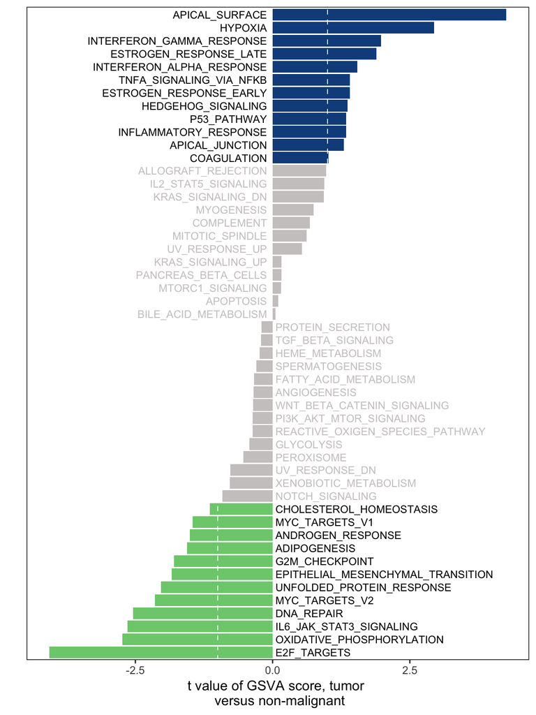

```r
ggplot(sortdf, aes(ID, score, fill = group)) + geom_bar(stat = 'identity') +
  coord_flip() +
  scale_fill_manual(values = c('palegreen3', 'snow3', 'dodgerblue4'), guide = FALSE) +

  #画2条虚线
  geom_hline(yintercept = c(-cutoff,cutoff),
             color="white",
             linetype = 2, #画虚线
             size = 0.3) + #线的粗细

  #写label
  geom_text(data = subset(df, score < 0),
            aes(x=ID, y= 0, label= paste0(" ", ID), color = group),#bar跟坐标轴间留出间隙
            size = 3, #字的大小
            hjust = "inward" ) +  #字的对齐方式
  geom_text(data = subset(df, score > 0),
            aes(x=ID, y= -0.1, label=ID, color = group),
            size = 3, hjust = "outward") +
  scale_colour_manual(values = c("black","snow3","black"), guide = FALSE) +

  xlab("") +ylab("t value of GSVA score, tumor \n versus non-malignant")+
  theme_bw() + #去除背景色
  theme(panel.grid =element_blank()) + #去除网格线
  theme(panel.border = element_rect(size = 0.6)) + #边框粗细
  theme(axis.line.y = element_blank(), axis.ticks.y = element_blank(), axis.text.y = element_blank()) #去除y轴
```

```r
ggsave("gsva.pdf", width = 6, height = 8)
```